# Notebook TP 0¶

You will use this notebook to answer the exercises. You can add text (markdown) or code cells as you see fit, but you are not allowed to delete cells.

In this first session, we take control of the software: we experiment the visualizing methods of two variable functions (graph and isovalues)

# Visualization of a 2d function

In a code cell, load the libraries numpy, math and matplotlib + specific 3D tools

```python
import numpy as np
import matplotlib.pyplot as plt
import math
from mpl_toolkits.mplot3d import Axes3D
from matplotlib import cm

%matplotlib inline
```

Consider the 3 functions \begin{eqnarray} quad: R^n\rightarrow R, \quad quad(X)&=&\frac{1}{2}\langle Ax,x\rangle+\langle b,x\rangle +c,\quad A\in R^{n\times n},~b\in R^n,~c\in R\\ f24:R^2\rightarrow R, \quad f24(X)&=& {(x_1-2)^2+(x_2-3)^4}, \\ rast: R^n\rightarrow R,\quad rast(X)&=&n+||X||^2-\sum_{i=1}^n\cos(\beta x_i), \mbox{ with } \beta=5. \end{eqnarray}

```python
A=np.array([[3.,-0.2],[-0.2,2.]])
B=np.array([-2.6,-3.8])
X=np.array([1.,2.])
C=5.1
print (X,A,B,C)
print (X.shape,A.shape)
```

```
[1. 2.] [[ 3.  -0.2]
 [-0.2  2. ]] [-2.6 -3.8] 5.1
(2,) (2, 2)
```

Program a function quad(X), the arrays $A$, $B$ and the float $C$ are globally defined

```python
def quad(X):
### BEGIN SOLUTION
    if not isinstance(X, np.ndarray):
        raise ValueError(" X input argument shoud be numpy array")
    if X.shape != (2,):
        raise ValueError("invalid shape for X input argument")
    return np.dot(np.dot(A,X),X)/2+np.dot(B,X)+C
### END SOLUTION
```

Test your function on the values defined above. You should get 0 for quad(X,A,B,C)

```python
assert quad(X)==0.0
assert quad(np.array([1.,1.])) == 0.9999999999999991
```

Check that your function returns an error if the arrays do not have the correct shape

```python
### BEGIN SOLUTION
quad(X) # will function
# quad(A) # will return an error
### END SOLUTION
```

```
0.0
```

The following cell draws the graph and isovalues of the quad function

```
[[0. 0. 0. ... 0. 0. 0.]
 [0. 0. 0. ... 0. 0. 0.]
 [0. 0. 0. ... 0. 0. 0.]
 ...
 [0. 0. 0. ... 0. 0. 0.]
 [0. 0. 0. ... 0. 0. 0.]
 [0. 0. 0. ... 0. 0. 0.]]
```

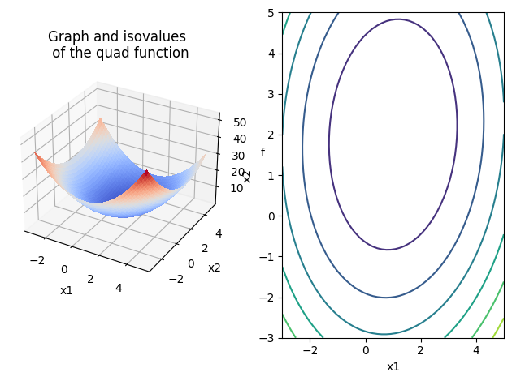

```python
n1=50
n2=40
x1_=np.linspace(-3.,5.,n1)
x2_=np.linspace(-3.,5.,n2)
s_=np.zeros((n2,n1))
#sx1_=np.zeros((n1,n2))
#sx2_=np.zeros((n1,n2))
print (s_)
sx1_,sx2_=np.meshgrid(x1_,x2_)
for i in range(n1):
    for j in range (n2):
        s_[j,i]=quad(np.array([x1_[i],x2_[j]]))
#print s_, sx1_,sx2_
fig = plt.figure()
fig.clf()

ax = fig.add_subplot(121, projection='3d')

ax.plot_surface(sx1_,sx2_,s_,rstride=1, cstride=1, cmap=cm.coolwarm,
                       linewidth=0, antialiased=False)
ax.set_xlabel('x1')
ax.set_ylabel('x2')
ax.set_zlabel('f')
ax.set_title('Graph and isovalues \n of the quad function')
ay = fig.add_subplot(122)

ay.contour(sx1_,sx2_,s_)
ay.set_xlabel('x1')
ay.set_ylabel('x2')
fig.tight_layout()


#ax.contour(sx1_,sx2_,s_)
```

Adapt the above code to define a function displaying the graph and isovalues of a function passed in input

```python
def plot_function(fun,center,dimensions):
    # fun : name of the function to be drawn
    # center : center of the display area (list or np.array of length 2)
    # dimensions :half dimensions of the display area  (list or np.array of length 2)
    # your code below
    ### BEGIN SOLUTION
    n1=50
    n2=40
    x1_=np.linspace(center[0]-dimensions[0],center[0]+dimensions[0],n1)
    x2_=np.linspace(center[1]-dimensions[1],center[1]+dimensions[1],n2)
    s_=np.zeros((n2,n1))


    sx1_,sx2_=np.meshgrid(x1_,x2_)
    for i in range(n1):
        for j in range (n2):
            s_[j,i]=fun(np.array([x1_[i],x2_[j]]))
    fig = plt.figure()
    fig.clf()

    ax = fig.add_subplot(121, projection='3d')

    ax.plot_surface(sx1_,sx2_,s_,rstride=1, cstride=1, cmap=cm.coolwarm,
                       linewidth=0, antialiased=False)
    ax.set_xlabel('x1')
    ax.set_ylabel('x2')
    ax.set_zlabel('f')
    ax.set_title('Graph and isovalues \n of the quad function')
    ay = fig.add_subplot(122)

    ay.contour(sx1_,sx2_,s_)
    ay.set_xlabel('x1')
    ay.set_ylabel('x2')
    fig.tight_layout()
    ### END SOLUTION
```

Test the plot_function function on the quad function

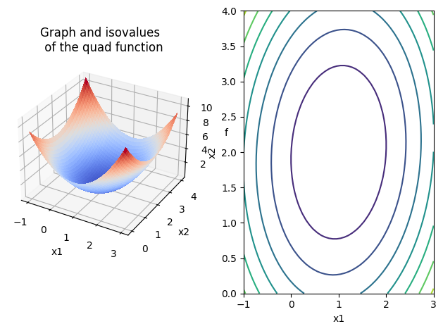

```python
### BEGIN SOLUTION
plot_function(quad,[1,2],[2,2])
### END SOLUTION
```

Program functions $f23(x)$. This function should take a numpy array of shape (2,) as input argument.

```python
def f23(x):
    ### BEGIN SOLUTION
    return (x[0]-2.)**2+(x[1]-3.)**4
    ### END SOLUTION
```

```python
X=np.array([1.,2.])
assert f23(X)==2.0
```

Program function $rast(x)$. This function should take a numpy array of shape (2,) as input argument

```python
def rast(x):
    ### BEGIN SOLUTION
    beta=5.
    y=len(x)+np.linalg.norm(x)**2-np.sum(np.cos(beta*x))
    return y
    ### END SOLUTION
```

```python
X=np.array([1.,2.])
assert rast(X)==7.555409343613227
```

Draw the graph and isovalues of function $f23$ for an interesting range values.

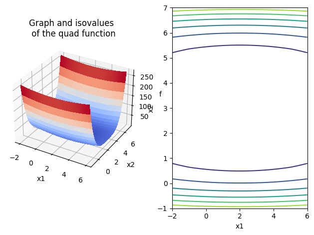

```python
### BEGIN SOLUTION
center=[2,3]
dimensions=[4,4]
plot_function(f23,center, dimensions)
### END SOLUTION
```

Draw the graph and isovalues of function $rast$ for an interesting range values.

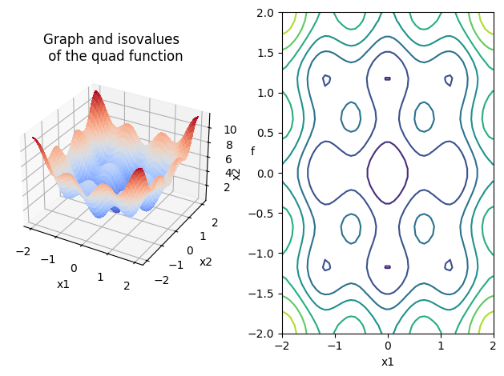

```python
### BEGIN SOLUTION
center=[0,0]
dimensions=[2,2]
plot_function(rast,center, dimensions)
### END SOLUTION
```

Modify the function plot_function so that it also draws a red cross in a given point $x_x$ sent in input as an optionnal $4^{th}$ argument.

```python
def plot_function(fun,center,dimensions,point=center):
    # fun : name of the function to be drawn
    # center : center of the display area (list or np.array of length 2)
    # dimensions :half dimensions of the display area  (list or np.array of length 2)
    # point : location for a red cross
    # your code below
    ### BEGIN SOLUTION
    n1=50
    n2=40
    x1_=np.linspace(center[0]-dimensions[0],center[0]+dimensions[0],n1)
    x2_=np.linspace(center[1]-dimensions[1],center[1]+dimensions[1],n2)
    s_=np.zeros((n2,n1))


    sx1_,sx2_=np.meshgrid(x1_,x2_)
    for i in range(n1):
        for j in range (n2):
            s_[j,i]=fun(np.array([x1_[i],x2_[j]]))
    fig = plt.figure()
    fig.clf()

    ax = fig.add_subplot(121, projection='3d')

    ax.plot_surface(sx1_,sx2_,s_,rstride=1, cstride=1, cmap=cm.coolwarm,
                       linewidth=0, antialiased=False)
    ax.plot(point[0],point[1],fun(np.array(point)),'rx')

    ax.set_xlabel('x1')
    ax.set_ylabel('x2')
    ax.set_zlabel('f')
    ax.set_title('Graph and isovalues \n of the quad function')
    ay = fig.add_subplot(122)

    ay.contour(sx1_,sx2_,s_)
    ay.plot(point[0],point[1],'rx')
    ay.set_xlabel('x1')
    ay.set_ylabel('x2')
    fig.tight_layout()
    ### END SOLUTION
```

Test the modify $plot\_function$ on $f23$ and $rast$

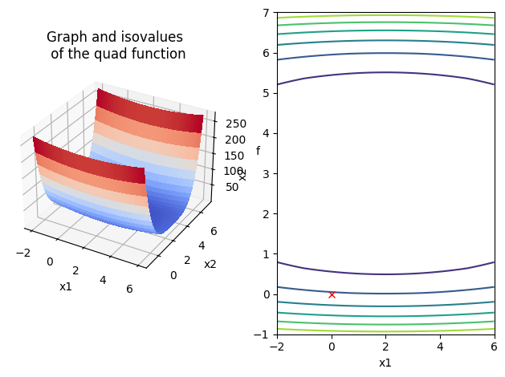

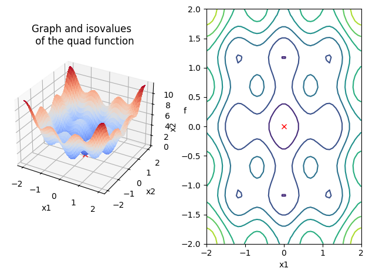

```python
### BEGIN SOLUTION
center=[2,3]
dimensions=[4,4]
plot_function(f23,center, dimensions)
center=[0,0]
dimensions=[2,2]
plot_function(rast,center, dimensions)
### END SOLUTION
```

### The following cells reproduce the example of level curves shown in class

```python
def circle(X):
    if not isinstance(X, np.ndarray):
        raise ValueError(" X input argument shoud be numpy array")
    if X.shape != (2,):
        raise ValueError("invalid shape for X input argument")
    return np.linalg.norm(X)**2
def circ_exp(X):
    if not isinstance(X, np.ndarray):
        raise ValueError(" X input argument shoud be numpy array")
    if X.shape != (2,):
        raise ValueError("invalid shape for X input argument")
    return np.exp(-X[0])*np.linalg.norm(X)**2
```

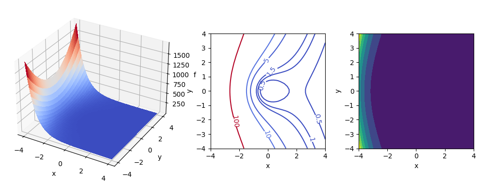

```python
import matplotlib.gridspec as gridspec
# This custom formatter removes trailing zeros, e.g. "1.0" becomes "1"
def fmt(x):
    s = f"{x:.1f}"
    if s.endswith("0"):
        s = f"{x:.0f}"
    return rf"{s}" if plt.rcParams["text.usetex"] else f"{s}"


def makefig3(fun):
    n1=50
    n2=40
    x1_=np.linspace(-4.,4.,n1)
    x2_=np.linspace(-4.,4.,n2)
    s_=np.zeros((n2,n1))
    sx1_,sx2_=np.meshgrid(x1_,x2_)
    for i in range(n1):
        for j in range (n2):
            s_[j,i]=fun(np.array([x1_[i],x2_[j]]))
    fig = plt.figure(figsize=(10, 6))
    fig.clf()
    gs = gridspec.GridSpec(1, 3, height_ratios=[1], width_ratios=[1.5, 1, 1])
    levels = [0.5,1,1.5,5,10,100]
    ax = plt.subplot(gs[0, 0], projection='3d')

    ax.plot_surface(sx1_,sx2_,s_,rstride=1, cstride=1, cmap=cm.coolwarm,
                       linewidth=0, antialiased=False)


    ax.set_xlabel('x')
    ax.set_ylabel('y')
    ax.set_zlabel('f')

    ay = plt.subplot(gs[0, 1])




    CS =ay.contour(sx1_,sx2_,s_,cmap=cm.coolwarm,levels=levels)

    ay.clabel(CS, CS.levels, inline=True, fmt=fmt, fontsize=10)

    ay.set_xlabel('x')
    ay.set_ylabel('y')
    ay.set_aspect('equal')

    az = plt.subplot(gs[0, 2])
    az.contourf(sx1_,sx2_,s_)
    az.set_xlabel('x')
    az.set_ylabel('y')
    az.set_aspect('equal')
    fig.tight_layout()

makefig3(circ_exp)
```

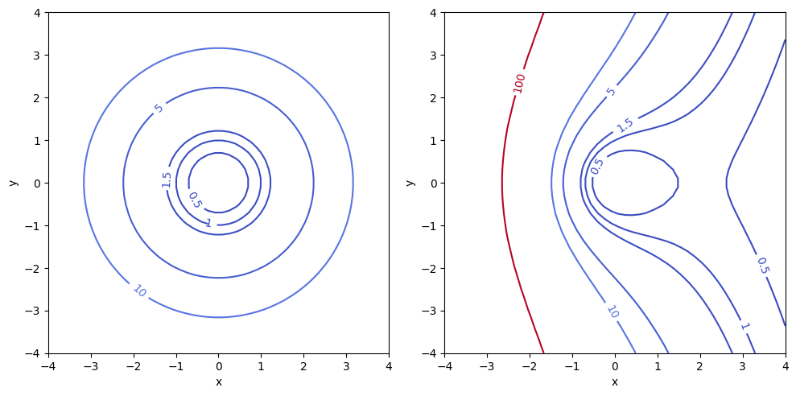

```python
def makefig2():
    n1=50
    n2=40
    x1_=np.linspace(-4.,4.,n1)
    x2_=np.linspace(-4.,4.,n2)
    s1_=np.zeros((n2,n1))
    s2_=np.zeros((n2,n1))
    sx1_,sx2_=np.meshgrid(x1_,x2_)
    for i in range(n1):
        for j in range (n2):
            s1_[j,i]=circle(np.array([x1_[i],x2_[j]]))
            s2_[j,i]=circ_exp(np.array([x1_[i],x2_[j]]))
    fig = plt.figure(figsize=(10, 6))
    fig.clf()
    gs = gridspec.GridSpec(1, 2, height_ratios=[1], width_ratios=[ 1, 1])
    levels = [0.5,1,1.5,5,10,100]

    ay = plt.subplot(gs[0, 0])
    CS =ay.contour(sx1_,sx2_,s1_,cmap=cm.coolwarm,levels=levels)
    ay.clabel(CS, CS.levels, inline=True, fmt=fmt, fontsize=10)
    ay.set_xlabel('x')
    ay.set_ylabel('y')
    ay.set_aspect('equal')

    az = plt.subplot(gs[0, 1])
    CS2 =az.contour(sx1_,sx2_,s2_,cmap=cm.coolwarm,levels=levels)
    az.clabel(CS2, CS2.levels, inline=True, fmt=fmt, fontsize=10)
    az.set_xlabel('x')
    az.set_ylabel('y')
    az.set_aspect('equal')
    fig.tight_layout()
    #plt.savefig('../FIGURES/contour.png')  uncomment if you want to save the picture
makefig2()
```